# SNA for twitter data - Customer Engagement through Social Media Case

Chaymae

Xoxoday.com is a company specializing in experiential gifting, and faces challenges in utilizing social media for customer engagement and acquisition. Despite its active presence on platforms such as Twitter, Facebook, LinkedIn, YouTube, and WhatsApp, and posting an average of three tweets per day, Xoxoday was not achieving the expected consumer engagement through these channels. This situation prompted the company to consider social network analysis (SNA) as a method to better understand the dynamics of customer interactions and the effectiveness of their social media strategies.

Note: For your reference, Interactive plots as well as the analysis/recommendations part are found at the end of the notebook. Thank you!

```r
library(dplyr)
library(tidyr)
library(readxl)
```

```r
library(igraph)
tweets_data <- read_excel("C:/Users/ci/Downloads/W19310-XLS-ENG.xlsx", sheet = "Tweets Data")
retweets_data <- read_excel("C:/Users/ci/Downloads/W19310-XLS-ENG.xlsx", sheet = "Retweets Data")
user_data <- read_excel("C:/Users/ci/Downloads/W19310-XLS-ENG.xlsx", sheet = "Twitter User Data")
colnames(retweets_data)
```

```
## [1] "Vertex 1" "Vertex 2"
```

```r
colnames(tweets_data)
```

```
##  [1] "...1"              "...2"              "Visual Properties"
##  [4] "...4"              "...5"              "...6"
##  [7] "...7"              "Labels"            "...9"
## [10] "...10"             "Graph Metrics"     "Do Not Edit"
## [13] "...13"             "Other Columns"     "...15"
## [16] "...16"             "...17"             "...18"
## [19] "...19"             "...20"             "...21"
## [22] "...22"             "...23"             "...24"
## [25] "...25"             "...26"
```

```r
colnames(user_data)
```

```
##  [1] "T"                 "...2"              "Visual Properties"
##  [4] "...4"              "...5"              "...6"
##  [7] "...7"              "Labels"            "...9"
## [10] "...10"             "Graph Metrics"     "Do Not Edit"
## [13] "...13"             "Other Columns"     "...15"
## [16] "...16"             "...17"             "...18"
## [19] "...19"             "...20"             "...21"
## [22] "...22"             "...23"             "...24"
## [25] "...25"             "...26"
```

```r
# Checking total NA values in tweets_data
total_na_tweets <- sum(is.na(tweets_data))
# Doing the same for retweets_data
total_na_retweets <- sum(is.na(retweets_data))
# Doing the same for user_data
total_na_user <- sum(is.na(user_data))
# Getting the totals
print(total_na_tweets)
```

```
## [1] 69473
```

```r
print(total_na_retweets)
```

```
## [1] 0
```

```r
print(total_na_user)
```

```
## [1] 15620
```

• To match the purpose of this assignment, I would say that retweets unlike tweets that are original content, show how content is shared and spread and it can be a useful metric to analyze the reach as a measure of user engagement • When identifying user clusters, it will be relevant to analyze the users often being retweeted using this retweets dataset because they can be considered "influencers".

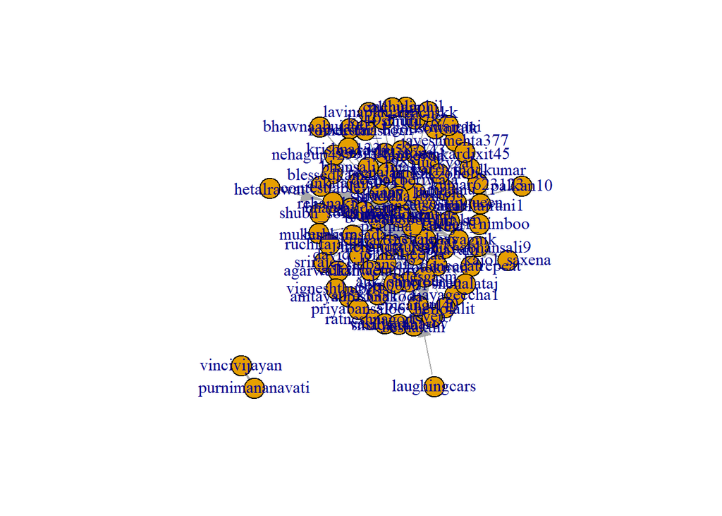

```r
#initial visualization of the network keeping retweets only
retweets_data <- retweets_data %>%
  filter(!is.na(`Vertex 1`) & !is.na(`Vertex 2`))
retweets_data <- retweets_data %>%
  mutate(`Vertex 1` = as.character(`Vertex 1`), `Vertex 2` = as.character(`Vertex 2`))
network_graph <- graph_from_data_frame(d = retweets_data, directed = TRUE)
plot(network_graph, layout = layout_with_fr(network_graph))
```

The graph above has been the initial visualization made to get a sense of the number of clusters if any and to identify if there are outliers.

```r
library(visNetwork)
```

```r
visIgraph(network_graph)
```

[interactive chart not shown]

```r
V(network_graph)$name
```

```
##  [1] "ratneshnagori"   "ankitajain0911"  "nehagup42992144" "rohit_se"
##  [5] "godsowntalk"     "ajayageecha1"    "jainnamu"        "romeromash"
##  [9] "shikhabhansali9" "jayeshmehta377"  "anitaya05853817" "bhansalidigna"
## [13] "smadan4u"        "sensible_mona"   "13bhavani"       "baljeetaa"
## [17] "mukeshksin"      "auk_sanejourno"  "srirajee1"       "kumar623123"
## [21] "mgossipqueen"    "achari_nimboo"   "rockstar_born"   "imbevda"
## [25] "soni00001"       "binny_kukreja"   "1985luckygal"    "palkan10"
## [29] "danceeatrepeat"  "anahitairani1"   "purnimananavati" "mehulgohil"
## [33] "fotokiran"       "rehanak55"       "zeniairani"      "humairasadaf_"
## [37] "girija_kriz"     "bhansali_jinal"  "blessedkamal"    "shubh_softy"
## [41] "le_kukzoholic"   "lavinapunjabi"   "karrivinodkumar" "epicangel40"
## [45] "laughingcars"    "kumar623"        "contestadventur" "agarwalkshweta"
## [49] "nehalroys"       "sidbansal22"     "akii_naik"       "nehayagnik"
## [53] "kajol_saxena"    "hellolalit"      "snehalataj"      "ruchitajain16"
## [57] "priyabansal66"   "k219shruti"      "hetalrawat"      "call_jain"
## [61] "shwtz7"          "bhawnaahuja007"  "8686841151rp"    "sureshnakoda"
## [65] "mehandisuresh"   "vasilykomarov"   "deepakberiwala"  "annu_dogra"
## [69] "reenajain89"     "shraddha_bari"   "david_john21"    "krishna1334"
## [73] "raghu587143"     "beshakthi"       "acharyaempire"   "b_elaine_"
## [77] "vineetsonkar"    "pratima_talreja" "salesgasm"       "omkardixit45"
## [81] "thexoxoday"      "dhuru787"        "vigneshthupli1"  "reachskk"
## [85] "vincivijayan"    "reyen7"          "contesttable"
```

```r
visIgraph(network_graph) %>%
  visNodes(title = V(network_graph)$name) %>%
  visEdges(arrows = "to") %>%
  visInteraction(navigationButtons = TRUE, keyboard = TRUE)
```

[interactive chart not shown]

The next visualization I made was this one above that shows the links through the connections lines and the central node ( when zooming in, the names of users are also visible)

```r
visIgraph(network_graph) %>%
  visOptions(highlightNearest = TRUE, nodesIdSelection = TRUE) %>%
  visInteraction(navigationButtons = TRUE, keyboard = TRUE)
```

[interactive chart not shown]

The next visualization I made was this one above that shows the links through the connections lines and the central node ( when zooming in, the names of users are also visible)

```r
visIgraph(network_graph) %>%
  visSave("network_visualization.html")
browseURL
```

[output not shown]

```r
library(htmlwidgets)
```

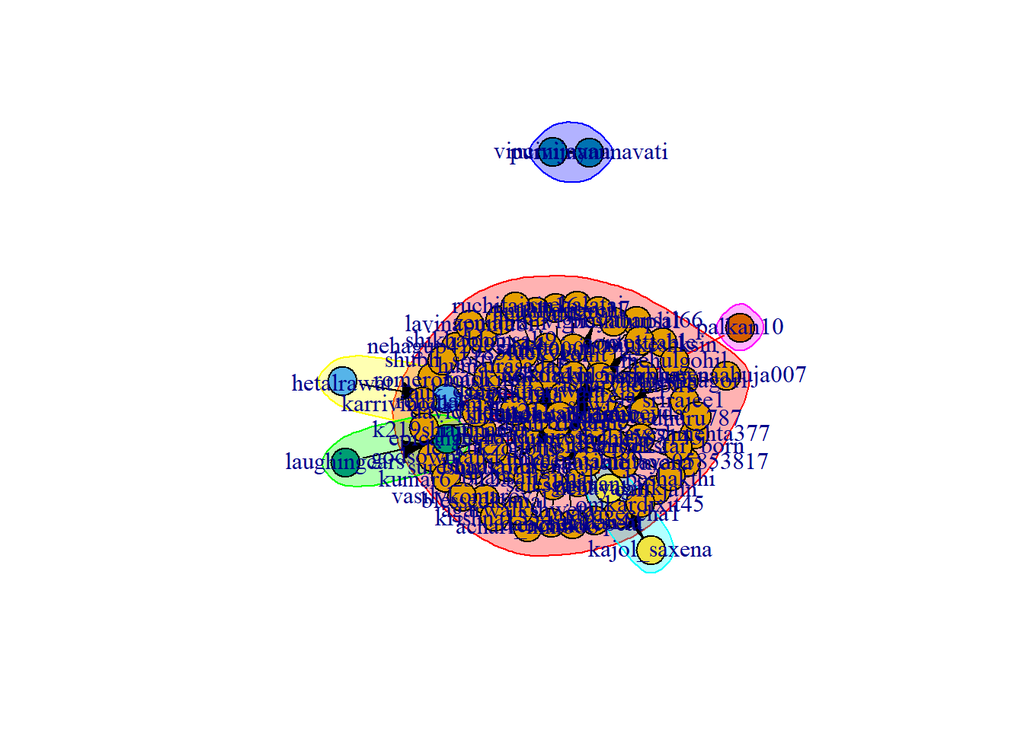

```r
communities <- cluster_walktrap(network_graph)

# Using the Walktrap communities method, now we plot the graph to identify clusters
plot(communities, network_graph)
```

```r
nodes_df <- data.frame(id = V(network_graph)$name,
                       group = membership(communities),
                       title = V(network_graph)$name,
                       label = V(network_graph)$name)

edges_df <- as_data_frame(network_graph, what = "edges")
nodes_df$group <- as.factor(membership(communities))
```

As you can see in the script, in the final lines I disabled the dynamic and moving effect of the graph and built a new clear static one that would serve for final analysis :

```r
visNetwork(nodes_df, edges_df) %>%
  visNodes(title = "title", label = "label", group = "group") %>%
  visEdges(arrows = 'to') %>%
  visOptions(highlightNearest = TRUE, nodesIdSelection = TRUE) %>%
  visLayout(randomSeed = 123)
```

[interactive chart not shown]

```r
visNetwork(nodes_df, edges_df) %>%
  visEdges(arrows = 'to') %>%
  visPhysics(enabled = FALSE)
```

[interactive chart not shown]

```r
degree_centrality <- degree(network_graph, mode="all")  # Total connections
in_degree <- degree(network_graph, mode="in")  # Incoming connections
out_degree <- degree(network_graph, mode="out")  # Outgoing connections
betweenness_centrality <- betweenness(network_graph, directed=TRUE)
closeness_centrality <- closeness(network_graph, mode="all")
```

```r
metrics <- list(
  DegreeCentrality = list(In = in_degree, Out = out_degree),
  BetweennessCentrality = betweenness_centrality,
  ClosenessCentrality = closeness_centrality
)
print(metrics)
```

```
## $DegreeCentrality
## $DegreeCentrality$In
##   ratneshnagori  ankitajain0911 nehagup42992144        rohit_se     godsowntalk
##               0               0               0               0               0
##    ajayageecha1        jainnamu      romeromash shikhabhansali9  jayeshmehta377
##               0               0               0               0               0
## anitaya05853817   bhansalidigna        smadan4u   sensible_mona       13bhavani
##               0               0               0               0               0
##       baljeetaa      mukeshksin  auk_sanejourno       srirajee1     kumar623123
##               0               0               0               0               0
##    mgossipqueen   achari_nimboo   rockstar_born         imbevda       soni00001
##               1               0               0               0               0
##   binny_kukreja    1985luckygal        palkan10  danceeatrepeat   anahitairani1
##               1               0               0               0               0
## purnimananavati      mehulgohil       fotokiran       rehanak55      zeniairani
##               0               0               0               1               0
##   humairasadaf_     girija_kriz  bhansali_jinal    blessedkamal     shubh_softy
##               0               0               0               0               0
##   le_kukzoholic   lavinapunjabi karrivinodkumar     epicangel40    laughingcars
##               0               0               0               1               0
##        kumar623 contestadventur  agarwalkshweta       nehalroys     sidbansal22
##               0               0               0               0               0
##       akii_naik      nehayagnik    kajol_saxena      hellolalit      snehalataj
##               0               1               1               0               0
##   ruchitajain16   priyabansal66      k219shruti      hetalrawat       call_jain
##               0               0               0               0               0
##          shwtz7  bhawnaahuja007    8686841151rp    sureshnakoda   mehandisuresh
##               1               0               0               0               1
##   vasilykomarov  deepakberiwala      annu_dogra     reenajain89   shraddha_bari
##               0               2               0               0               0
##    david_john21     krishna1334     raghu587143       beshakthi   acharyaempire
##               0               0               0               0               0
##       b_elaine_    vineetsonkar pratima_talreja       salesgasm    omkardixit45
##               0               2               1               1               0
##      thexoxoday        dhuru787  vigneshthupli1        reachskk    vincivijayan
##             450               0               0               0               1
##          reyen7    contesttable
##               1               1
##
## $DegreeCentrality$Out
```

[output cut: 98 more lines]

```
##     0.005813953     0.005882353     0.003952569     0.005813953     0.005813953
##   ruchitajain16   priyabansal66      k219shruti      hetalrawat       call_jain
##     0.005813953     0.005813953     0.005813953     0.003952569     0.005813953
##          shwtz7  bhawnaahuja007    8686841151rp    sureshnakoda   mehandisuresh
##     0.005882353     0.003952569     0.005813953     0.005847953     0.005847953
##   vasilykomarov  deepakberiwala      annu_dogra     reenajain89   shraddha_bari
##     0.005813953     0.005813953     0.005813953     0.005813953     0.005813953
##    david_john21     krishna1334     raghu587143       beshakthi   acharyaempire
##     0.005813953     0.005813953     0.005813953     0.005813953     0.005813953
##       b_elaine_    vineetsonkar pratima_talreja       salesgasm    omkardixit45
##     0.005813953     0.005813953     0.005813953     0.005813953     0.005813953
##      thexoxoday        dhuru787  vigneshthupli1        reachskk    vincivijayan
##     0.011235955     0.005813953     0.005813953     0.005813953     1.000000000
##          reyen7    contesttable
##     0.005813953     0.005813953
```

```r
# network density
network_density <- edge_density(network_graph)
print(network_density)
```

```
## [1] 0.06241647
```

The density of 0.06241647 means that about 6.24% of all possible connections are actually realized ==> moderate connectivity : while there is some interaction among users, the network is not highly interconnected. Many potential connections among nodes are not being utilized.

```r
#average_path_length
average_path_length <- average.path.length(network_graph, directed = TRUE, unconnected = TRUE)
print(average_path_length)
```

```
## [1] 1.895548
```

Also: This value supports the small-world phenomenon often observed in social networks, where despite the large size of the network, the path length between nodes remains surprisingly short.

Given the big number of users, I will speak in general terms ( or rather in terms of general patterns I noticed):

• We can see that there a dense cluster of connected users at the center of the plot so we can say that these users interact very often.

• There is a node on the extreme right that has no connection to the central cluster so this is definitely a separate community with different interests and we can also consider them non or less influential or maybe they’re new twitter users.

| Xoxoday’s Social Media Strategy recommendations |
| --- |

• The separate communities should be further researched because they have different interests or topics around which they are separately connected away from central nodes, knowing this topic can help increase the reach because this would be a new segment in the audience.

```r
#Thank you for reviewing my work and your feedback is highly appreciated
```